# DS 202: Lab 2

MyTien Kien; kmytien, Tanner Dunn; tcdunn

2/15/2021

```r
choco <- read.csv("https://raw.githubusercontent.com/xdaiISU/ds202materials/master/hwlabs/data/choco.csv")
str(choco)
```

```
## 'data.frame':    2312 obs. of  13 variables:
##  $ REF                 : int  2454 2458 2454 797 797 1015 1019 1011 1019 1011 ...
##  $ Company             : chr  "5150" "5150" "5150" "A. Morin" ...
##  $ Location            : chr  "U.S.A." "U.S.A." "U.S.A." "France" ...
##  $ Date                : int  2019 2019 2019 2012 2012 2013 2013 2013 2013 2013 ...
##  $ Bean_Origin         : chr  "Madagascar" "Dominican Republic" "Tanzania" "Peru" ...
##  $ Specific_Bean_Origin: chr  "Bejofo Estate, batch 1" "Zorzal, batch 1" "Kokoa Kamili, batch 1" "Peru" ...
##  $ Cocoa_Percent       : num  76 76 76 63 70 70 63 70 70 70 ...
##  $ Ingredients         : chr  "3- B,S,C" "3- B,S,C" "3- B,S,C" "4- B,S,C,L" ...
##  $ Characteristics1    : chr  "cocoa" "cocoa" "rich cocoa" "fruity" ...
##  $ Characteristics2    : chr  "blackberry" "vegetal" "fatty" "melon" ...
##  $ Characteristics3    : chr  "full body" "savory" "bready" "roasty" ...
##  $ Characteristics4    : chr  NA NA NA NA ...
##  $ Rating              : num  3.75 3.5 3.25 3.75 3.5 4 4 3.75 3.5 3.25 ...
```

**1.** How are the ratings distributed? Create both a histogram and a boxplot and describe them. Don’t forget to mention outliers, if there are any.

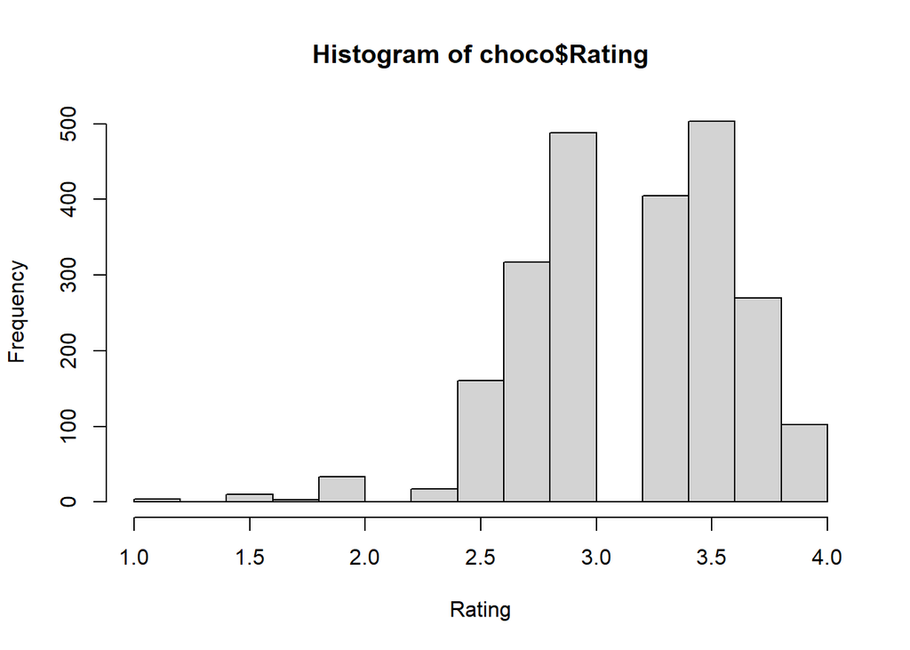

```r
hist(choco$Rating, xlab = 'Rating')
```

Shown here in the histogram, there are many outliers in the chocolate’s ratings. Most of these outliers are ratings of 1.0 to 2.0. Another thing about this histogram is that it’s skewed heavily to the left.

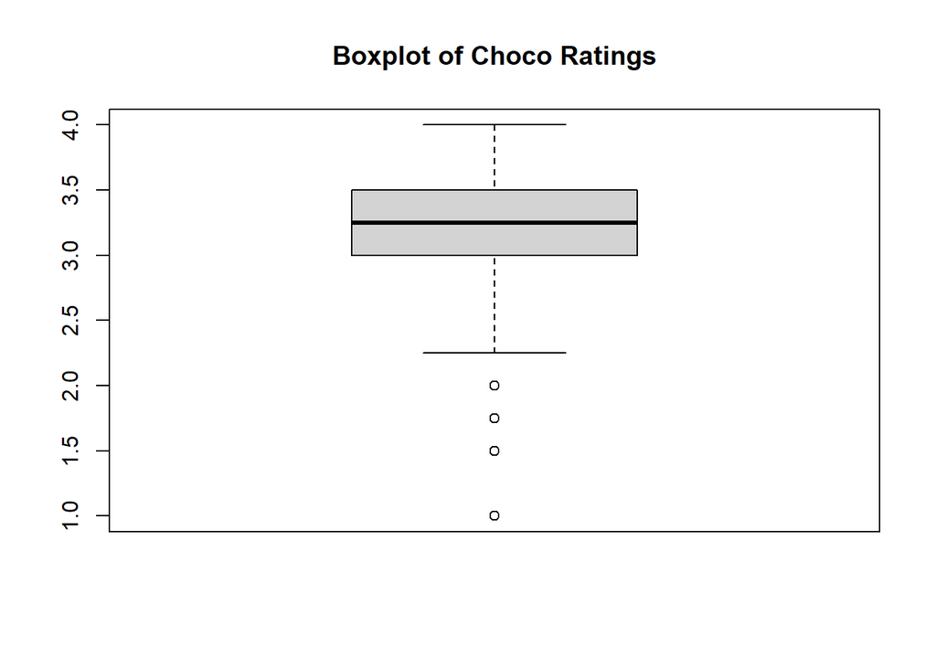

```r
boxplot(choco$Rating, main = 'Boxplot of Choco Ratings')
```

Shown here in the boxplot diagram, it shows that the median of all chocolate ratings are between 3.0 and 3.5. The outliers are also shown here, showing four outliers of 1.0, 1.5, 1.75 and 2.0. It shows the range being 2.25 to 4.0 (with the exception of the outliers).

**2.** How does the number of ratings depend on the location of the company? Draw a bar chart of the number of reports.

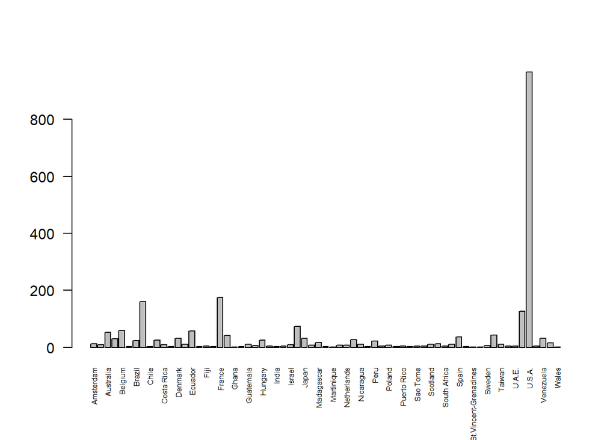

```r
barplot(table(choco$Location), las = 2, cex.names = 0.5)
```

From this barplot, I think the more developed/populated the country/location, the higher amount of ratings there are.

**3.** Do ratings depend on the cacao percentage of a chocolate bar? Create both numerical and graphical summaries, and explain.

```r
cor(choco$Cocoa_Percent, choco$Rating)
```

```
## [1] -0.1510178
```

```r
summary(choco[c("Cocoa_Percent", "Rating")])
```

```
##  Cocoa_Percent        Rating
##  Min.   : 42.00   Min.   :1.000
##  1st Qu.: 70.00   1st Qu.:3.000
##  Median : 70.00   Median :3.250
##  Mean   : 71.65   Mean   :3.184
##  3rd Qu.: 75.00   3rd Qu.:3.500
##  Max.   :100.00   Max.   :4.000
```

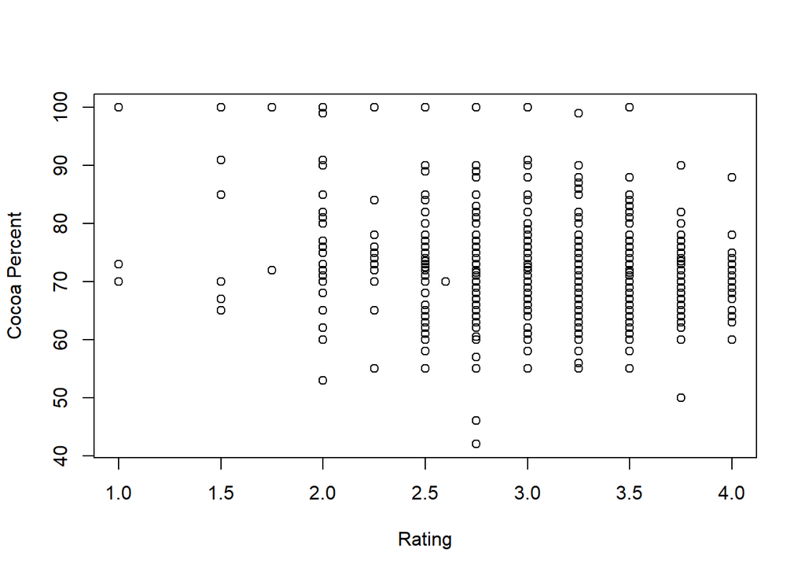

```r
plot(choco$Rating, choco$Cocoa_Percent, xlab = 'Rating', ylab = 'Cocoa Percent')
```

**4.** How do different bean origins compare in terms of the flavor of chocolates? Are beans from some places better than the other? Create both numerical and graphical summaries, and explain.

```r
#Print out the top 30 Ratings of bean origins
origin_ratings <- aggregate(Rating ~ Bean_Origin, data = choco, FUN= max)
head(origin_ratings[order(-origin_ratings$Rating),], n = 30)
```

```
##           Bean_Origin Rating
## 2              Belize   4.00
## 4               Blend   4.00
## 5             Bolivia   4.00
## 7              Brazil   4.00
## 10           Colombia   4.00
## 12         Costa Rica   4.00
## 16            Ecuador   4.00
## 20              Ghana   4.00
## 22          Guatemala   4.00
## 23              Haiti   4.00
## 26          Indonesia   4.00
## 28            Jamaica   4.00
## 30         Madagascar   4.00
## 33             Mexico   4.00
```

[output cut: 16 more lines]

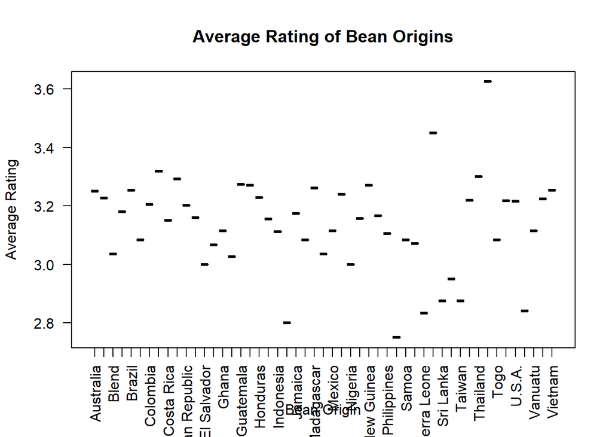

```r
#group by origin
origin <- group_by(choco, choco$Bean_Origin)
#get the average ratings and count
origin1 <- summarise(origin, ave_rating = mean(Rating, na.rm=TRUE), count = n())
#filter out all of the places that only had one rating (there were a lot)
origin2 <- filter(origin1, count>1)
plot(x=factor(origin2$`choco$Bean_Origin`), y=origin2$ave_rating, las = 2, ylab = 'Average Rating', xlab = 'Bean Origin', main = "Average Rating of Bean Origins")
```

```r
#barplot(origin2$ave_rating ~ origin2$`choco$Bean_Origin`, las = 2, ylab = 'Average Rating', xlab = 'Bean Origin')
```

From the numerical data looking at the top rated bean origin’s ratings you can see the 24 bean origin’s that have produced a rating of 4.0 which is the highest. Then we decided to graph the mean rating’s of Bean_Origin. There isn’t a ton of variability but Tobago stand out with the highest mean. In conclusion a bean’s origin does not seem to have a big impact on the chocolate’s rating.

**5.** Brainstorm two analyses you would like to perform (with your teammates). Describe in plain language what comparisons are you making. Create suitable numerical and graphical summaries for your analyses. Describe the results.

```r
above70 <- choco[choco$Cocoa_Percent >= '70%', ]
below70 <- choco[choco$Cocoa_Percent < '70%', ]
mean(above70$Rating)
```

```
## [1] 3.136111
```

```r
mean(below70$Rating)
```

```
## [1] 3.220008
```

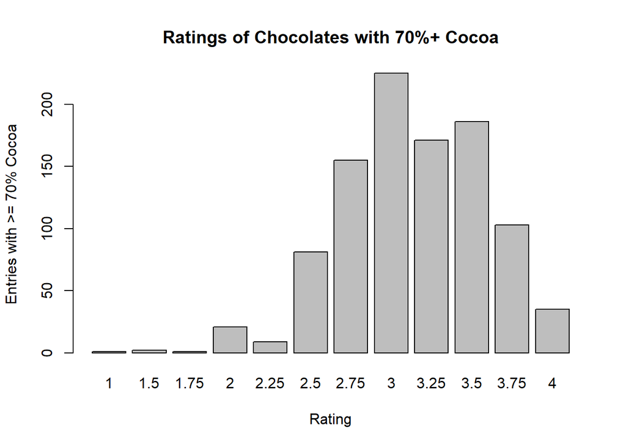

```r
barplot(table(above70$Rating), xlab = 'Rating', ylab = 'Entries with >= 70% Cocoa', main = 'Ratings of Chocolates with 70%+ Cocoa')
```

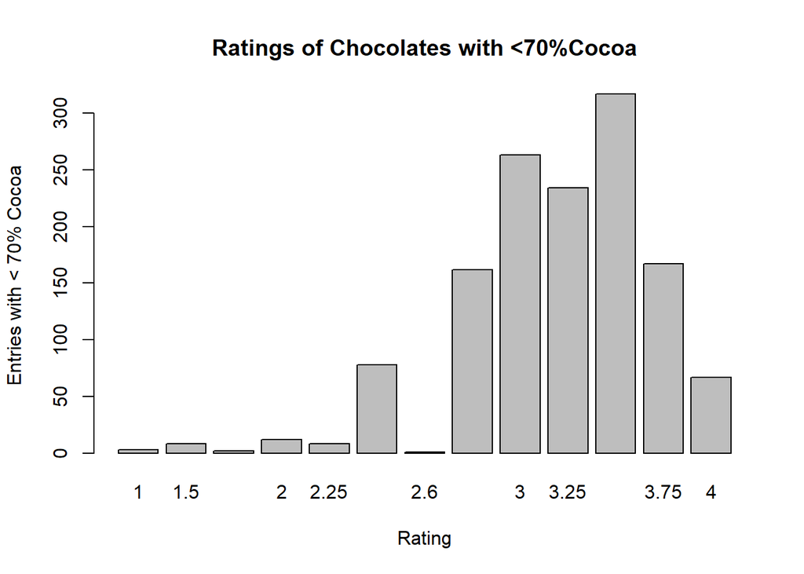

```r
barplot(table(below70$Rating), xlab = 'Rating', ylab = 'Entries with < 70% Cocoa', main = 'Ratings of Chocolates with <70%Cocoa')
```

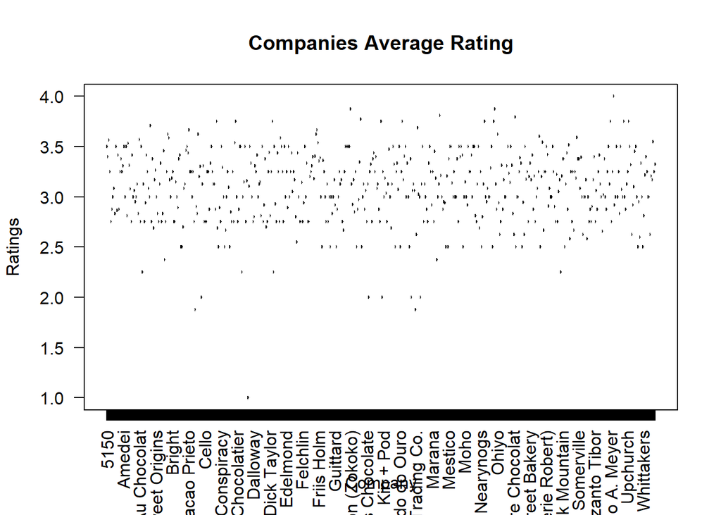

```r
CRatings <- group_by(choco, choco$Company)
CRatings2 <- summarise(CRatings, Comp_Rating = mean(Rating, na.rm=TRUE))
CRatings3 <- head(order(factor(CRatings2$Comp_Rating), decreasing = TRUE), n = 10)
plot(x=factor(CRatings2$`choco$Company`), y=CRatings2$Comp_Rating, las = 2, ylab = 'Ratings', xlab = 'Company', main = 'Companies Average Rating')
```

```r
choco$Company[CRatings3]
```

```
##  [1] "Chocolate Makers"                  "Bitacora"
##  [3] "Cacao Prieto"                      "Brazen"
##  [5] "Cacaosuyo (Theobroma Inversiones)" "Bittersweet Origins"
##  [7] "Anahata"                           "Arete"
##  [9] "Artisan du Chocolat"               "Blue Bandana"
```